# Prediction Writeup

JBB

4/16/2017

### Summary

Using devices such as Jawbone Up, Nike FuelBand, and Fitbit it is now possible to collect a large amount of data about personal activity relatively inexpensively. These type of devices are part of the quantified self movement – a group of enthusiasts who take measurements about themselves regularly to improve their health, to find patterns in their behavior, or because they are tech geeks. One thing that people regularly do is quantify how much of a particular activity they do, but they rarely quantify how well they do it.

### Question

The goal will be to use data from accelerometers on the belt, forearm, arm, and dumbell of 6 participants. They were asked to perform barbell lifts correctly and incorrectly in 5 different classes.

1. training data: https://d396qusza40orc.cloudfront.net/predmachlearn/pml-training.csv
2. test data: https://d396qusza40orc.cloudfront.net/predmachlearn/pml-testing.csv

### Load and Clean the Data

```r
library(ggplot2);
library(rattle);
library(RColorBrewer);
library(rpart.plot);
library(e1071)
library(caret);
library(rpart);
library(randomForest)
```

Read the data from the provided urls and exclude invalid data as well:

```r
url.train <- "https://d396qusza40orc.cloudfront.net/predmachlearn/pml-training.csv"
url.test <- "https://d396qusza40orc.cloudfront.net/predmachlearn/pml-testing.csv"
training <- read.csv(url(url.train), na.strings = c("NA", "", "#DIV0!"))
testing <- read.csv(url(url.test), na.strings = c("NA", "", "#DIV0!"))
```

Take a look at the size and dimention of the data:

```r
dim (training)
```

```
## [1] 19622   160
```

```r
dim (testing)
```

```
## [1]  20 160
```

The data contains 19622 observations of 160 variables for training and 20 observations of the same variables for testing. Some columns in the training and testing datasets are filled with missing values hence removed from dataset.

```r
training <-training[,colSums(is.na(training)) == 0]
testing <-testing[,colSums(is.na(testing)) == 0]
head(colnames(training))
```

```
## [1] "X"                    "user_name"            "raw_timestamp_part_1"
## [4] "raw_timestamp_part_2" "cvtd_timestamp"       "new_window"
```

The first seven variables of the training data were deleted as well, since they are irrelevant and connot contribute to the prediction.

```r
training <- training[,8:dim(training)[2]]
testing <- testing[,8:dim(testing)[2]]
dim (training)
```

```
## [1] 19622    53
```

```r
dim (testing)
```

```
## [1] 20 53
```

We used tranining part (60%), testing part (20%), and validation part (20%) to partition the data.

```r
set.seed(4976)
dataSet1 <- createDataPartition(y = training$classe, p = 0.8, list = F)
dataSet2 <- training[dataSet1,]
validation <- training[-dataSet1,]
training_1 <- createDataPartition(y = dataSet2$classe, p = 0.75, list = F)
training_2 <- dataSet2[training_1,]
testing_data <- dataSet2[-training_1,]
```

## Predictors

Let’s look at the distribution of the classes-data:

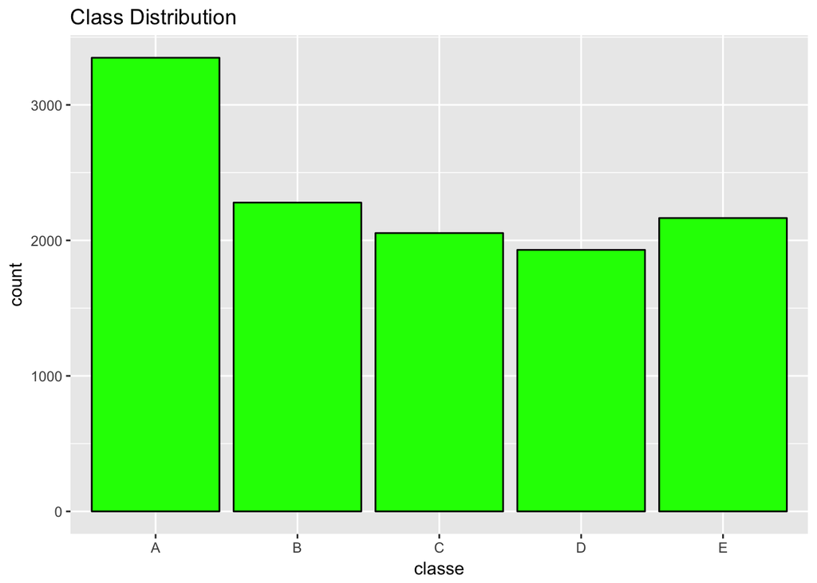

```r
qplot(classe, data=training_2, main="Class Distribution", fill=I("green"), col=I("black"))
```

and the predictors are among:

```r
names(training_2[,-53])
```

```
##  [1] "roll_belt"            "pitch_belt"           "yaw_belt"
##  [4] "total_accel_belt"     "gyros_belt_x"         "gyros_belt_y"
##  [7] "gyros_belt_z"         "accel_belt_x"         "accel_belt_y"
## [10] "accel_belt_z"         "magnet_belt_x"        "magnet_belt_y"
## [13] "magnet_belt_z"        "roll_arm"             "pitch_arm"
## [16] "yaw_arm"              "total_accel_arm"      "gyros_arm_x"
## [19] "gyros_arm_y"          "gyros_arm_z"          "accel_arm_x"
## [22] "accel_arm_y"          "accel_arm_z"          "magnet_arm_x"
## [25] "magnet_arm_y"         "magnet_arm_z"         "roll_dumbbell"
## [28] "pitch_dumbbell"       "yaw_dumbbell"         "total_accel_dumbbell"
## [31] "gyros_dumbbell_x"     "gyros_dumbbell_y"     "gyros_dumbbell_z"
## [34] "accel_dumbbell_x"     "accel_dumbbell_y"     "accel_dumbbell_z"
## [37] "magnet_dumbbell_x"    "magnet_dumbbell_y"    "magnet_dumbbell_z"
## [40] "roll_forearm"         "pitch_forearm"        "yaw_forearm"
## [43] "total_accel_forearm"  "gyros_forearm_x"      "gyros_forearm_y"
## [46] "gyros_forearm_z"      "accel_forearm_x"      "accel_forearm_y"
## [49] "accel_forearm_z"      "magnet_forearm_x"     "magnet_forearm_y"
## [52] "magnet_forearm_z"
```

```r
tree <- rpart(classe ~ ., data=training_2, method="class")
prediction_tree <- predict(tree, testing_data, type="class")
class_tree <- confusionMatrix(prediction_tree, testing_data$classe)
class_tree
```

```
## Confusion Matrix and Statistics
##
##           Reference
## Prediction    A    B    C    D    E
##          A 1034  152    9   53   13
##          B   36  397   42   10   39
##          C   26  121  587   70   89
##          D   15   43   45  450   38
##          E    5   46    1   60  542
##
## Overall Statistics
##
##                Accuracy : 0.7673
##                  95% CI : (0.7537, 0.7804)
##     No Information Rate : 0.2845
##     P-Value [Acc > NIR] : < 2.2e-16
##
##                   Kappa : 0.7045
##  Mcnemar's Test P-Value : < 2.2e-16
##
## Statistics by Class:
##
##                      Class: A Class: B Class: C Class: D Class: E
## Sensitivity            0.9265   0.5231   0.8582   0.6998   0.7517
## Specificity            0.9191   0.9599   0.9055   0.9570   0.9650
## Pos Pred Value         0.8200   0.7576   0.6573   0.7614   0.8287
## Neg Pred Value         0.9692   0.8935   0.9680   0.9421   0.9452
## Prevalence             0.2845   0.1935   0.1744   0.1639   0.1838
## Detection Rate         0.2636   0.1012   0.1496   0.1147   0.1382
## Detection Prevalence   0.3214   0.1336   0.2276   0.1507   0.1667
## Balanced Accuracy      0.9228   0.7415   0.8819   0.8284   0.8584
```

We can see that the Accuracy : 0.7673 with 95% CI : (0.7537, 0.7804). The the Decision Tree looks like:

[figure not shown]

```r
rpart.plot(tree, main="Decision Tree ", under=TRUE, faclen=0)
```

We can see the classification of the data. Let’s applying the model to the Random forest data

```r
forest_model <- randomForest(classe ~ ., data=training_2, method="class")
prediction_forest <- predict(forest_model, testing_data, type="class")
random_forest <- confusionMatrix(prediction_forest, testing_data$classe)
random_forest
```

```
## Confusion Matrix and Statistics
##
##           Reference
## Prediction    A    B    C    D    E
##          A 1116    5    0    0    0
##          B    0  749    7    0    0
##          C    0    5  677    5    2
##          D    0    0    0  638    4
##          E    0    0    0    0  715
##
## Overall Statistics
##
##                Accuracy : 0.9929
##                  95% CI : (0.9897, 0.9953)
##     No Information Rate : 0.2845
##     P-Value [Acc > NIR] : < 2.2e-16
##
##                   Kappa : 0.991
##  Mcnemar's Test P-Value : NA
##
## Statistics by Class:
##
##                      Class: A Class: B Class: C Class: D Class: E
## Sensitivity            1.0000   0.9868   0.9898   0.9922   0.9917
## Specificity            0.9982   0.9978   0.9963   0.9988   1.0000
## Pos Pred Value         0.9955   0.9907   0.9826   0.9938   1.0000
## Neg Pred Value         1.0000   0.9968   0.9978   0.9985   0.9981
## Prevalence             0.2845   0.1935   0.1744   0.1639   0.1838
## Detection Rate         0.2845   0.1909   0.1726   0.1626   0.1823
## Detection Prevalence   0.2858   0.1927   0.1756   0.1637   0.1823
## Balanced Accuracy      0.9991   0.9923   0.9930   0.9955   0.9958
```

### Prediction

```r
prediction1 <- predict(forest_model, newdata=testing_data)
confusionMatrix(prediction1, testing_data$classe)
```

```
## Confusion Matrix and Statistics
##
##           Reference
## Prediction    A    B    C    D    E
##          A 1116    5    0    0    0
##          B    0  749    7    0    0
##          C    0    5  677    5    2
##          D    0    0    0  638    4
##          E    0    0    0    0  715
##
## Overall Statistics
##
##                Accuracy : 0.9929
##                  95% CI : (0.9897, 0.9953)
##     No Information Rate : 0.2845
##     P-Value [Acc > NIR] : < 2.2e-16
##
##                   Kappa : 0.991
##  Mcnemar's Test P-Value : NA
##
## Statistics by Class:
##
##                      Class: A Class: B Class: C Class: D Class: E
## Sensitivity            1.0000   0.9868   0.9898   0.9922   0.9917
## Specificity            0.9982   0.9978   0.9963   0.9988   1.0000
## Pos Pred Value         0.9955   0.9907   0.9826   0.9938   1.0000
## Neg Pred Value         1.0000   0.9968   0.9978   0.9985   0.9981
## Prevalence             0.2845   0.1935   0.1744   0.1639   0.1838
## Detection Rate         0.2845   0.1909   0.1726   0.1626   0.1823
## Detection Prevalence   0.2858   0.1927   0.1756   0.1637   0.1823
## Balanced Accuracy      0.9991   0.9923   0.9930   0.9955   0.9958
```

From the results we can see that The Random Forest is a better predictive model than the Decision Tree. The accuracy rate is significantly larger. So that, there is no need for more important predictors for the Random Forest model.